# Exploratory Data Analysis in R - Transforming like a Data… Transformer

Greg Chism

2022/Oct/03

## Purpose of Workshop

**Using data transformation to correct non-normality in numerical data**

## Objectives

1. Load and explore a data set with publication quality tables
2. Quickly diagnose non-normality in data
3. Data transformation
4. Prepare an HTML summary report showcasing data transformations

## Required Setup

We first need to prepare our environment with the necessary packages

```r
# Sets the number of significant figures to two - e.g., 0.01
options(digits = 2)

# Required package for quick package downloading and loading
if (!require(pacman))
  install.packages("pacman")

# Downloads and load required packages
pacman::p_load(dlookr, # Exploratory data analysis
               forecast, # Needed for Box-Cox transformations
               formattable, # HTML tables from R outputs
               here, # Standardizes paths to data
               kableExtra, # Alternative to formattable
               knitr, # Needed to write HTML reports
               missRanger, # To generate NAs
               tidyverse) # Powerful data wrangling package suite
```

## Load and Examine a Data Set

- Load data and view
- Examine columns and data types
- Examine data normality
- Describe properties of data

```r
# Let's load a data set from the diabetes data set
dataset <- read.csv(here("EDA_In_R_Book", "data", "diabetes.csv")) |>
  # Add a categorical group
  mutate(Age_group = ifelse(Age >= 21 & Age <= 30, "Young",
                            ifelse(Age > 30 & Age <= 50, "Middle",
                                   "Elderly")),
         Age_group = fct_rev(Age_group))

# What does the data look like?
dataset |>
  head() |>
  formattable()
```

| Pregnancies | Glucose | BloodPressure | SkinThickness | Insulin | BMI | DiabetesPedigreeFunction | Age | Outcome | Age_group |
| --- | --- | --- | --- | --- | --- | --- | --- | --- | --- |
| 6 | 148 | 72 | 35 | 0 | 34 | 0.63 | 50 | 1 | Middle |
| 1 | 85 | 66 | 29 | 0 | 27 | 0.35 | 31 | 0 | Middle |
| 8 | 183 | 64 | 0 | 0 | 23 | 0.67 | 32 | 1 | Middle |
| 1 | 89 | 66 | 23 | 94 | 28 | 0.17 | 21 | 0 | Young |
| 0 | 137 | 40 | 35 | 168 | 43 | 2.29 | 33 | 1 | Middle |
| 5 | 116 | 74 | 0 | 0 | 26 | 0.20 | 30 | 0 | Young |

### Data Normality

Normal distributions (bell curves) are a common data assumptions for many [hypothesis testing statistics](https://en.wikipedia.org/wiki/Statistical_hypothesis_testing), in particular [parametric statistics](https://en.wikipedia.org/wiki/Parametric_statistics). Deviations from normality can either strongly skew the results or reduce the power to detect a [significant statistical difference](https://en.wikipedia.org/wiki/Statistical_significance).

Here are the distribution properties to know and consider:

- The mean, median, and mode are the same value.
- Distribution symmetry at the mean.
- Normal distributions can be described by the mean and standard deviation.

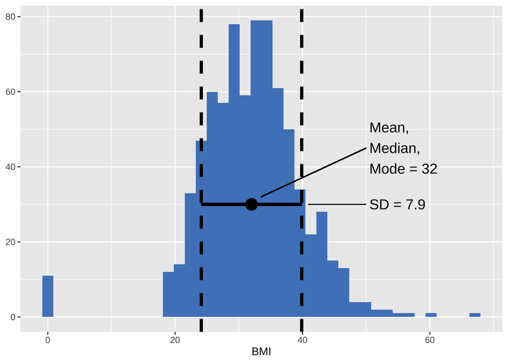

```r
# Function for data mode
getmode <- function(v) {
   uniqv <- unique(v)
   uniqv[which.max(tabulate(match(v, uniqv)))]
}

dataset |>
  ggplot(aes(x = BMI)) +
  geom_histogram(fill = "#4E84C4", size = 2, bins = 40) +
  geom_point(aes(y = 30, x = mean(BMI)), size = 5) +
  geom_point(aes(y = 30, x = median(BMI)), size = 5) +
  geom_point(aes(y = 30, x = getmode(BMI)), size = 5) +
  geom_vline(aes(xintercept = mean(BMI) - sd(BMI)), size = 1.5, linetype = "dashed") +
  geom_vline(aes(xintercept = mean(BMI) + sd(BMI)), size = 1.5, linetype = "dashed") +
  geom_segment(aes(y = 30, yend = 30, x = mean(BMI) - sd(BMI), xend = mean(BMI) + sd(BMI)), size = 1.5) +
  geom_segment(aes(y = 32, yend = 45, x = mean(BMI) + 1.5, xend = 50)) +
  geom_segment(aes(y = 30, yend = 30, x = mean(BMI) + sd(BMI) + 1, xend = 50)) +
  annotate(geom = "text", x = 50.5, y = 45, label = "Mean, \nMedian, \nMode = 32", size = 5, hjust = 0) +
  annotate(geom = "text", x = 50.5, y = 30, label = "SD = 7.9", size = 5, hjust = 0) +
  theme(axis.title.y = element_blank())
```

### Describing Properties of our Data (Refined)

#### Skewness

The symmetry of the distribution

```r
dataset |>
  select(Glucose, Insulin, BMI, SkinThickness) |>
  describe() |>
  select(described_variables, skewness) |>
  formattable()
```

| described_variables | skewness |
| --- | --- |
| Glucose | 0.17 |
| Insulin | 2.27 |
| BMI | -0.43 |
| SkinThickness | 0.11 |

Note that we will remove the other percentiles to produce a cleaner output

- `describes_variables`: name of the column being described
- `skewness`: skewness

## Testing Normality (Accelerated)

- Q-Q plots
- Testing overall normality of two columns
- Testing normality of groups

**Note** that you can also use `normality()` to run Shapiro-Wilk tests, but since this test is not viable at `N < 20`, I recommend just skipping to Q-Q plots.

#### Q-Q Plots

Plots of the quartiles of a target data set and plot it against predicted quartiles from a normal distribution.

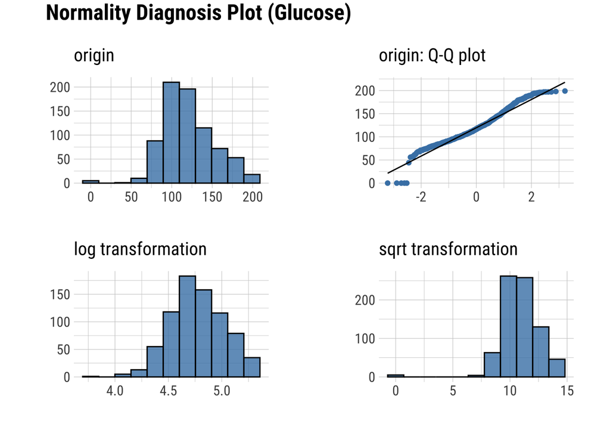

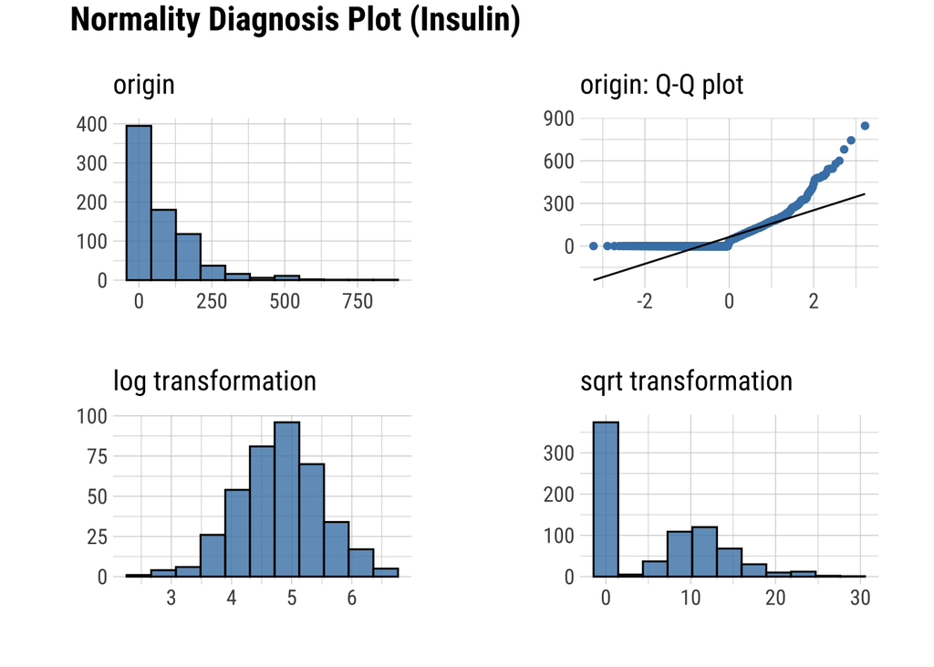

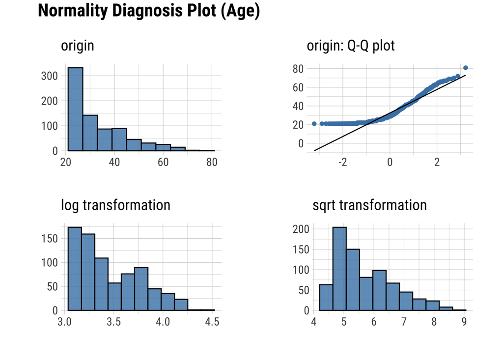

```r
dataset |>
plot_normality(Glucose, Insulin, Age)
```

## Normality within Groups

Looking within Age_group at the subgroup normality

#### Q-Q Plots

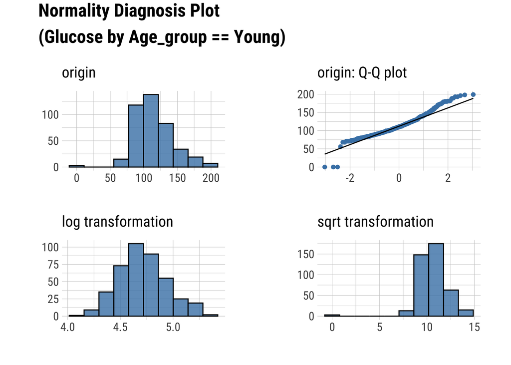

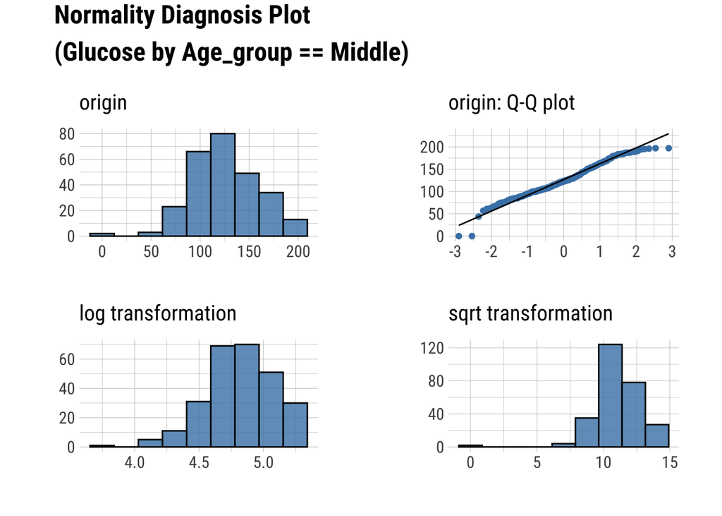

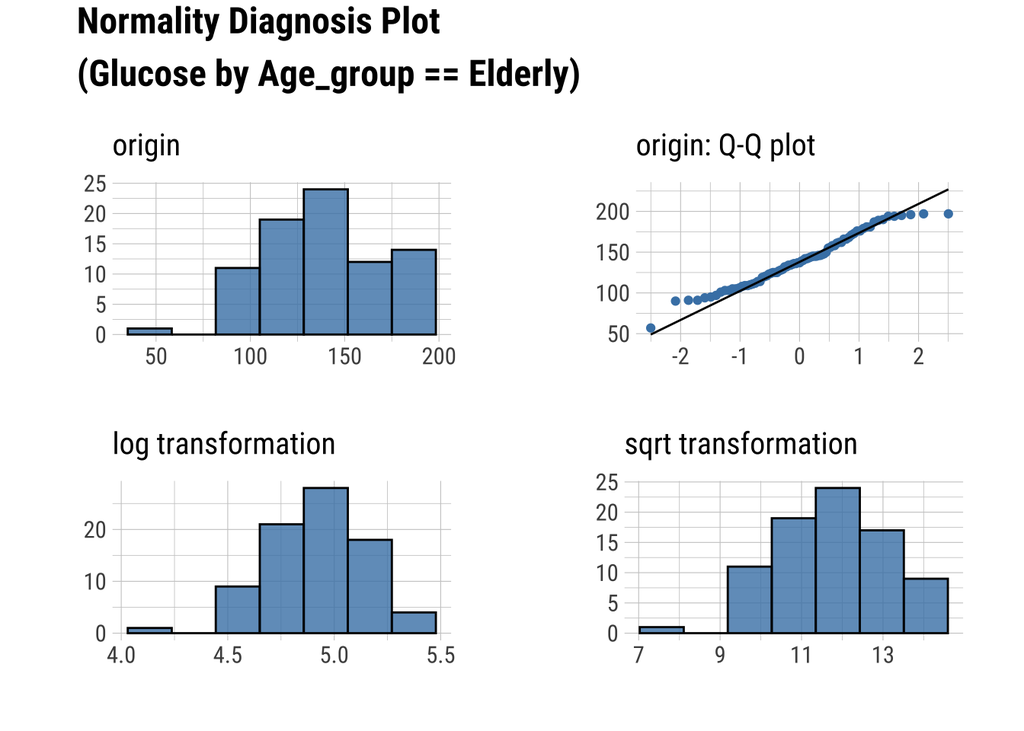

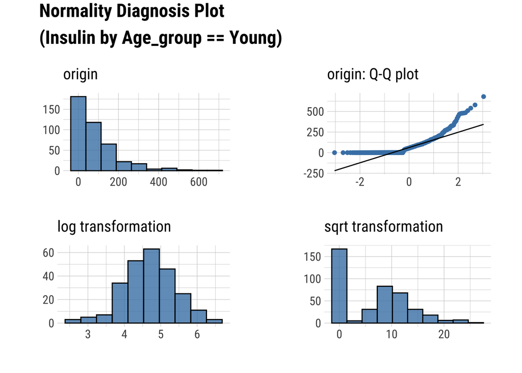

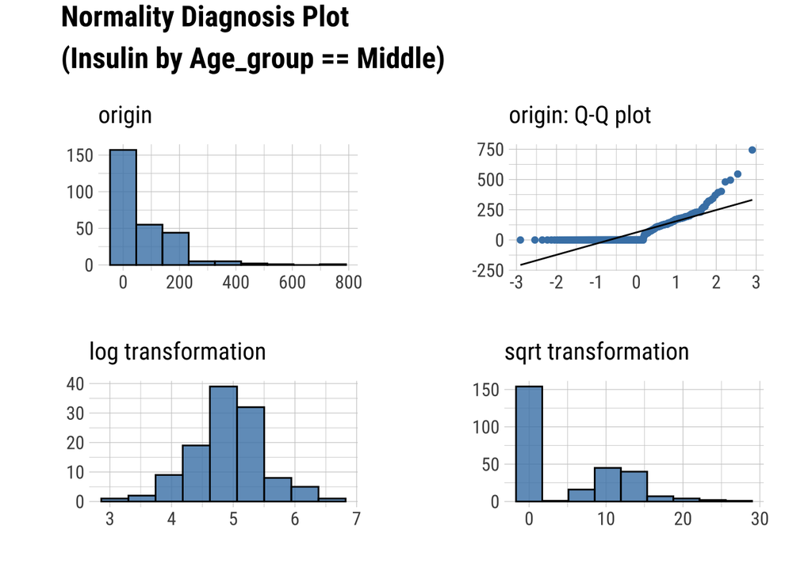

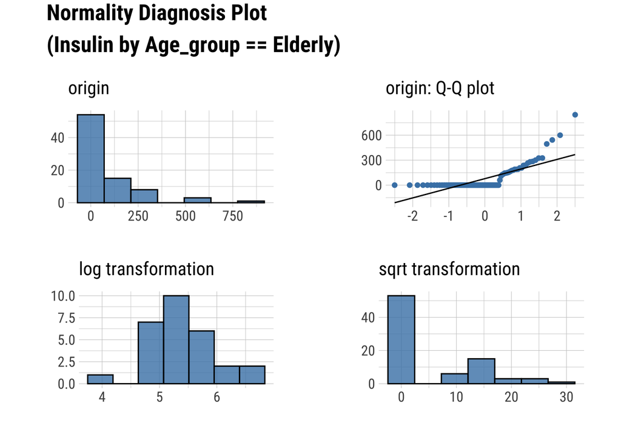

```r
dataset %>%
  group_by(Age_group) %>%
  select(Glucose, Insulin) %>%
  plot_normality()
```

## Transforming Data

Your data could be more easily interpreted with a transformation, since not all relationships in nature follow a linear relationship - i.e., many biological phenomena follow a power law (or logarithmic curve), where they do not scale linearly.

We will try to transform the `Insulin` column with through several approaches and discuss the pros and cons of each. First however, we will remove `0` values, because `Insulin` values are impossible…

```r
InsMod <- dataset |>
  filter(Insulin > 0)
```

### Square-root, Cube-root, and Logarithmic Transformations

Resolving Skewness using `transform()`.

“sqrt”: [square-root transformation](https://en.wikipedia.org/wiki/Square_root). $\sqrt x$ **(moderate skew)**

“log”: [log transformation](https://en.wikipedia.org/wiki/Logarithm). $log(x)$ **(greater skew)**

“log+1”: log transformation. $log(x + 1)$. Used for values that contain 0.

“1/x”: [inverse transformation](https://en.wikipedia.org/wiki/Inverse_function). $1/x$ **(severe skew)**

“x^2”: [squared transformation](https://en.wikipedia.org/wiki/Quadratic_function). $x^2$

“x^3”: [cubed transformation](https://en.wikipedia.org/wiki/Cubic_function). $x^3$

We will compare `sqrt`, `log+1`, and `1/x` (inverse) transformations. Note that you would have to add a constant to use the `log` transformation, so it is easier to use the `log+1` instead. You however need to add a constant to both the `sqrt` and `1/x` transformations because they don’t include zeros and will otherwise skew the results.

#### Square-root Transformation

```r
sqrtIns <- transform(InsMod$Insulin, method = "sqrt")

summary(sqrtIns)
```

```
## * Resolving Skewness with sqrt
##
## * Information of Transformation (before vs after)
##          Original Transformation
## n           394.0         394.00
## na            0.0           0.00
## mean        155.5          11.75
## sd          118.8           4.17
## se_mean       6.0           0.21
## IQR         113.8           5.05
## skewness      2.2           1.01
## kurtosis      6.4           1.46
## p00          14.0           3.74
## p01          18.0           4.24
## p05          41.7           6.45
## p10          50.3           7.09
## p20          69.2           8.32
## p25          76.2           8.73
## p30          87.9           9.38
## p40         105.0          10.25
## p50         125.0          11.18
## p60         145.8          12.07
## p70         176.0          13.27
## p75         190.0          13.78
## p80         210.0          14.49
## p90         292.4          17.10
## p95         395.5          19.89
## p99         580.5          24.09
## p100        846.0          29.09
```

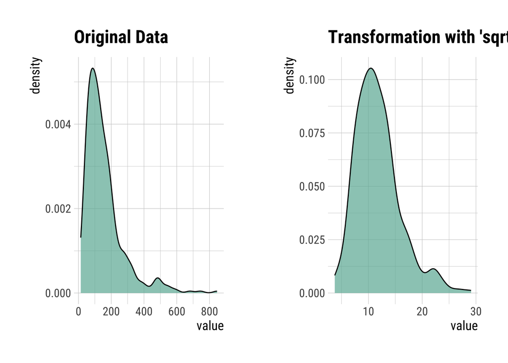

```r
sqrtIns |>
  plot()
```

#### Logarithmic (+1) Transformation

```r
Log1Ins <- transform(InsMod$Insulin, method = "log+1")

summary(Log1Ins)
```

```
## * Resolving Skewness with log+1
##
## * Information of Transformation (before vs after)
##          Original Transformation
## n           394.0        394.000
## na            0.0          0.000
## mean        155.5          4.818
## sd          118.8          0.691
## se_mean       6.0          0.035
## IQR         113.8          0.905
## skewness      2.2         -0.088
## kurtosis      6.4          0.237
## p00          14.0          2.708
## p01          18.0          2.944
## p05          41.7          3.753
## p10          50.3          3.938
## p20          69.2          4.251
## p25          76.2          4.347
## p30          87.9          4.488
## p40         105.0          4.663
## p50         125.0          4.836
## p60         145.8          4.989
## p70         176.0          5.176
## p75         190.0          5.252
## p80         210.0          5.352
## p90         292.4          5.682
## p95         395.5          5.983
## p99         580.5          6.366
## p100        846.0          6.742
```

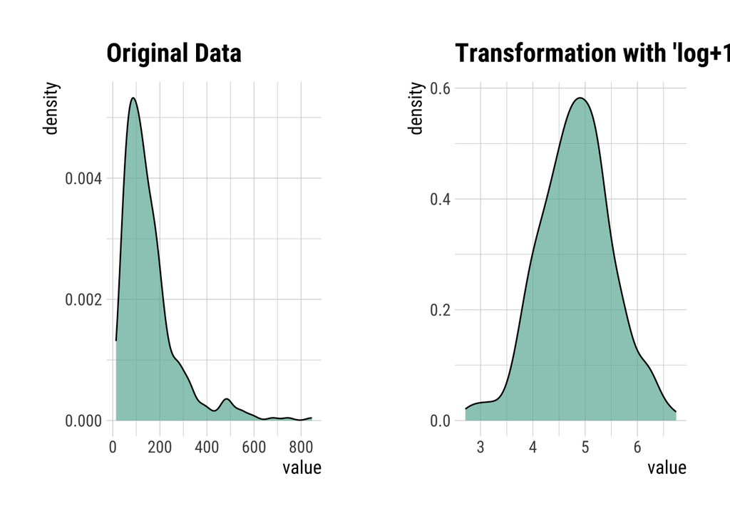

```r
Log1Ins |>
  plot()
```

#### Inverse Transformation

```r
InvIns <- transform(InsMod$Insulin, method = "1/x")

summary(InvIns)
```

```
## * Resolving Skewness with 1/x
##
## * Information of Transformation (before vs after)
##          Original Transformation
## n           394.0        3.9e+02
## na            0.0        0.0e+00
## mean        155.5        1.1e-02
## sd          118.8        9.0e-03
## se_mean       6.0        4.6e-04
## IQR         113.8        7.9e-03
## skewness      2.2        3.2e+00
## kurtosis      6.4        1.5e+01
## p00          14.0        1.2e-03
## p01          18.0        1.7e-03
## p05          41.7        2.5e-03
## p10          50.3        3.4e-03
## p20          69.2        4.8e-03
## p25          76.2        5.3e-03
## p30          87.9        5.7e-03
## p40         105.0        6.9e-03
## p50         125.0        8.0e-03
## p60         145.8        9.5e-03
## p70         176.0        1.1e-02
## p75         190.0        1.3e-02
## p80         210.0        1.4e-02
## p90         292.4        2.0e-02
## p95         395.5        2.4e-02
## p99         580.5        5.6e-02
## p100        846.0        7.1e-02
```

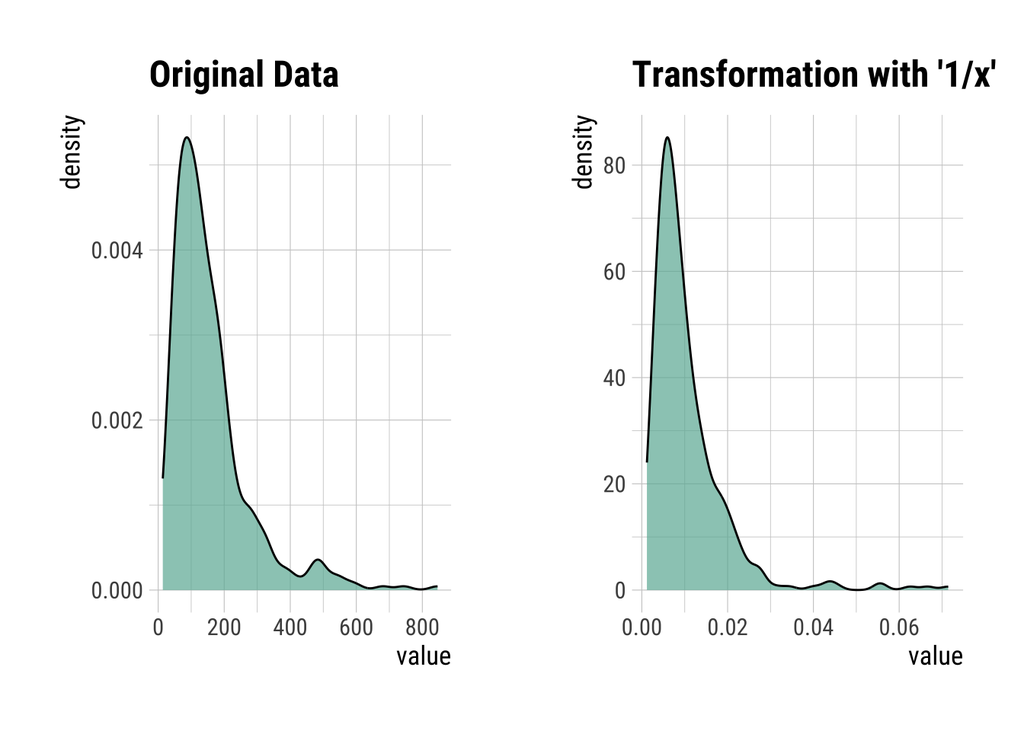

```r
InvIns |>
  plot()
```

### Box-cox Transformation

There are several transformations, each with it’s own “criteria”, and they don’t always fix extremely skewed data. Instead, you can just choose the [Box-Cox transformation](https://en.wikipedia.org/wiki/Box%E2%80%93Cox_distribution) which searches for the the best lambda value that maximizes the log-likelihood (basically, what power transformation is best). The benefit is that you should have normally distributed data after, but the power relationship might be pretty abstract (i.e., what would a transformation of x^0.12 be interpreted as in your system?..)

```r
BoxCoxIns <- transform(InsMod$Insulin, method = "Box-Cox")

summary(BoxCoxIns)
```

```
## * Resolving Skewness with Box-Cox
##
## * Information of Transformation (before vs after)
##          Original Transformation
## n           394.0        394.000
## na            0.0          0.000
## mean        155.5          3.011
## sd          118.8          0.262
## se_mean       6.0          0.013
## IQR         113.8          0.335
## skewness      2.2         -0.630
## kurtosis      6.4          1.003
## p00          14.0          2.027
## p01          18.0          2.168
## p05          41.7          2.588
## p10          50.3          2.673
## p20          69.2          2.808
## p25          76.2          2.848
## p30          87.9          2.904
## p40         105.0          2.973
## p50         125.0          3.037
## p60         145.8          3.092
## p70         176.0          3.157
## p75         190.0          3.183
## p80         210.0          3.216
## p90         292.4          3.320
## p95         395.5          3.409
## p99         580.5          3.515
## p100        846.0          3.610
```

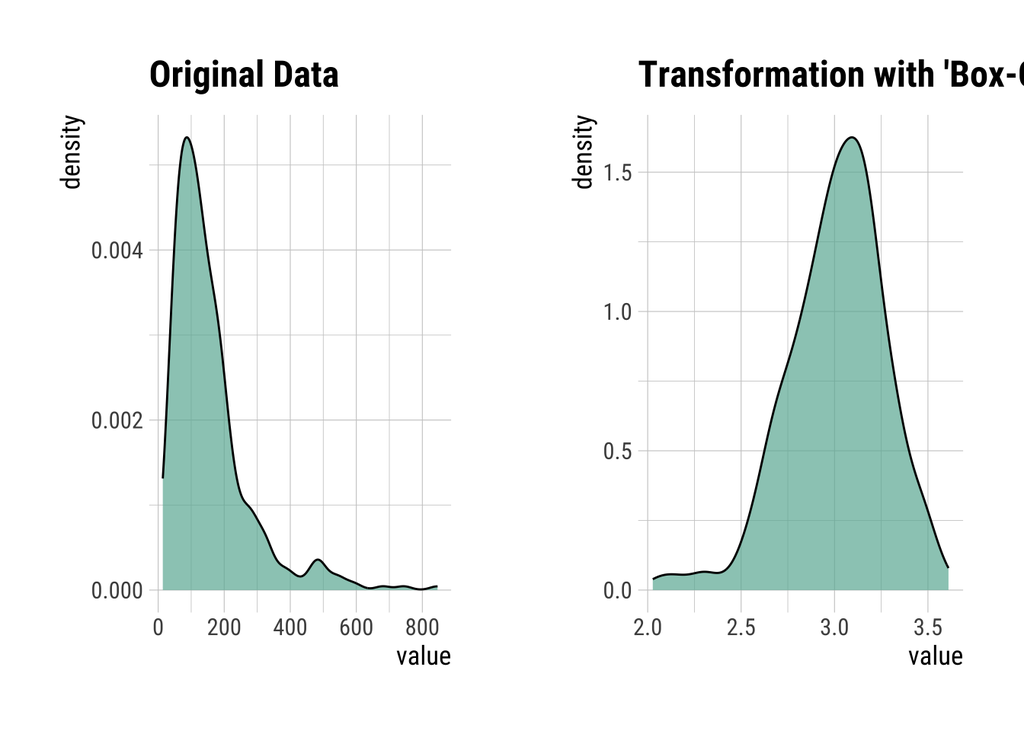

```r
BoxCoxIns |>
  plot()
```

## Produce an HTML Transformation Summary

```r
# Remove the '#' below to reproduce an HTML from an R script.
# transformation_web_report(dataset)
```